# Hierarchical logistic regression models in Stan

```r
library("rstanarm")
library("ggplot2")
library("bayesplot")
library("dplyr")
```

```r
options(mc.cores = parallel::detectCores())
```

### Load the data

```r
cps <- readRDS('cps_2016.RDS')
pstrat <- readRDS('frame.RDS')
```

Let’s fit the following model in rstanarm

$$y_n \sim \text{Binomial}(K_n, p_n) \\
\text{logit}(p_n) = \alpha + \alpha^\text{age}_{j[n]} +
\alpha^\text{state}_{k[n]} +
X_n \times \beta\\
\alpha^\text{age}_j = \sigma_{\text{age}}\times \eta^\text{age}_j \\
\alpha^\text{state}_k = \sigma_{\text{state}} \times \eta^\text{state}_k \\
\eta^\text{age}_j, \eta^\text{state}_k \sim \text{Normal}(0, 1) \\
\pi \sim \text{Dirichlet}(\nu) \\
\sigma_\text{global} \sim \text{exponential}(1) \\
\vec{\sigma} = \sqrt{c \times \pi \times \sigma_\text{global}^2} \\
\sigma_\text{age} = \vec{\sigma}_{[1]} \\
\sigma_\text{state} = \vec{\sigma}_{[2]}$$

This is a fairly complex model, takes about 80 lines to code this up in Stan code. We can do it in a few lines in rstanarm. What’s more, we don’t have to keep track of the differences between the poststratification frame and the fitted data.

```r
cps %>%
  group_by(
    age,state
  ) %>%
  summarise(
    vote = sum(vote),
    K = sum(N),
    did_not_vote = K - vote,
    state_pres_vote = first(state_pres_vote)
  ) %>%
  mutate(
    age_pred = as.integer(age)
  ) -> cps_rstanarm
pstrat %>%
  group_by(
    age, state
  ) %>%
  summarise(
    cell_elig = sum(N_elig),
    state_pres_vote = first(state_pres_vote)
  )  %>%
  mutate(
    age_pred = as.integer(age)
  ) -> pstrat_rstanarm
```

## Fit the model

Rstanarm models are specified using `lmer4` syntax.

```r
fit1 <-
  stan_glmer(
    cbind(vote, did_not_vote) ~ 1 +
    state_pres_vote + age_pred + (1 | age) +
      (1 | state),
    data = cps_rstanarm,
    iter = 1000,
    adapt_delta = 0.8,
    family = binomial(link = "logit"),
    QR = TRUE
  )
```

```
## trying deprecated constructor; please alert package maintainer
```

### Using shinystan

```r
library("shinystan")
ss_mod <- as.shinystan(fit1)
launch_shinystan(ss_mod)
```

### Posterior predictive checks

[figure not shown]

```r
pp_fit1 <- posterior_predict(fit1, newdata = fit1$data)

state_sel_vec <- fit1$data$state %in% c('HI','ME','OH')
ppc_stat_grouped(y = (fit1$data$vote / fit1$data$K)[state_sel_vec],
                 yrep = sweep(pp_fit1[,state_sel_vec], 2, STATS = fit1$data$K[state_sel_vec], FUN = '/'),
                 group = fit1$data$state[state_sel_vec], stat = min)
```

## Postrat

```r
ps_draws <-
  posterior_linpred(
    fit1,
    transform = TRUE,
    newdata = pstrat_rstanarm
  )

dim(ps_draws)
```

```
## [1] 2000 1050
```

```r
state_intervals <-
  intervals_of_interest(
    ps = pstrat_rstanarm,
    group_facs = 'state',
    cell_counts = 'cell_elig',
    ps_reps = ps_draws,
    probs = c(0.05, 0.25, 0.5, 0.75, 0.95)
  )

age_intervals <-
  intervals_of_interest(
    ps = pstrat_rstanarm,
    group_facs = 'age',
    cell_counts = 'cell_elig',
    ps_reps = ps_draws,
    probs = c(0.05, 0.25, 0.5, 0.75, 0.95)
  )
```

### Poststrat interval plots

We can plot our intervals 2 ways. The first is with the intervals that we have calculated.

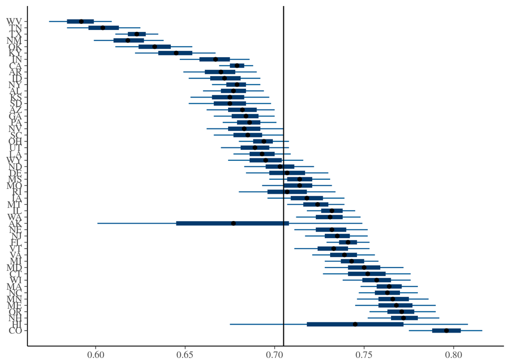

```r
theme_set(bayesplot::theme_default())
n_ints <- nrow(state_intervals$intervals)
overall_median <- median(state_intervals$intervals[,'50%'])
state_ints <-
  state_intervals$intervals %>%
  arrange(
    `95%`
  ) %>%
  mutate(
    y = seq(n_ints, 1, by = -1)
  )
state_names <- state_ints$group
y <- state_ints$y

p1 <- ggplot(state_ints) +
  geom_segment(aes(x = `5%`, xend = `95%`, y = y, yend = y), colour = '#005b96') +
  geom_segment(aes(x = `25%`, xend = `75%`, y = y, yend=y),size = 2, colour = '#03396c') +
  geom_point(aes(x = `50%`, y = y)) +
  scale_y_continuous(breaks = y, labels = state_names) +
  xlab(NULL) + ylab(NULL) +
  geom_vline(xintercept = overall_median)
p1
```

We can also use `bayesplot` to make our interval plots

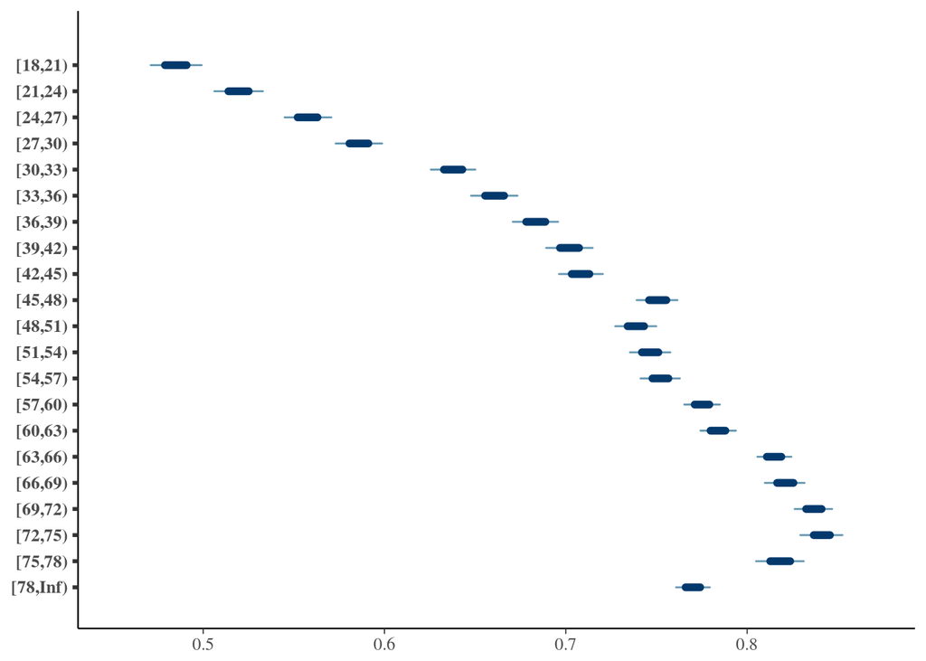

```r
df <- data.frame(age_intervals$dists)
names(df) <- names(age_intervals$dists)

mcmc_intervals(df, point_est = "none")
```

### Hierarchical scale priors

One thing to keep in mind when fitting models is that defining the hierarchy of the scale parameters of the random intercepts can improve sampling, decrease posterior intervals, and improve out-of-sample forecasts.

Sophie (Yajuan) Si, Jonah Gabry, Andrew Gelman, and I have been working on a prior for hierarhcical scale parameters in models where we have random intercepts that are two-way and three-way interactions between main categories.

For instance, if we wanted to fit the following model:

```r
fit2 <-
  stan_glmer(
    cbind(vote, did_not_vote) ~ 1 +
    state_pres_vote + age_pred + (1 | age) +
      (1 | state) + (1 | edu) + (1 | age:state) +
      (1 | age:edu) + (1 | state:edu),
    data = cps_rstanarm,
    iter = 1000,
    adapt_delta = 0.8,
    family = binomial(link = "logit"),
    QR = TRUE
  )
```

rstanarm would automatically treat the prior for the scale parameters for `age:state`, `age:edu` and `state:edu` the same as it would `state` and `age`. To review, the default prior for rstanarm is to use:

But our prior should probably reflect that if `age` isn’t an informative grouping for our data, then `age:state` probably won’t be useful either. We can encode that intuition by making the parameter $\sigma_\text{age:state} \propto \sigma_\text{age} \times \sigma_\text{state}$

We might also imagine learning a separate scale parameter for all of the K-way interactions, along with a global scale, akin to the parameterization of rstanarm’s prior over scale parameters. The full spec is below:

$$\sigma_\text{global} \sim \text{Student_t}^+(\nu, 0, \text{scale}) \\
\lambda_k^{(1)} \sim \text{Normal}^+(0, 1) \\
\lambda_k^{(l)} = \delta^{(l)} \prod_{l_0 \in M^{(k)}} \lambda_{l_0}^{(1)} \\
\delta^{(l)} \sim \text{Normal}^+(0, 1)$$
The priors for the random intercepts in the model above would become:

$$\alpha^\text{age}_j = \sigma_\text{global} \times \, \lambda^{(1)}_1 \times \eta^\text{age}_j \\
\alpha^\text{state}_j = \sigma_\text{global} \times \, \lambda^{(1)}_2 \times \eta^\text{state}_j \\
\alpha^\text{edu}_j = \sigma_\text{global} \times \, \lambda^{(1)}_3 \times \eta^\text{edu}_j \\
\alpha^{\text{age:state}}_j = \sigma_\text{global} \times \, \lambda^{(2)}_1 \times \eta^{\text{age:state}}_j \\
\alpha^{\text{age:edu}}_j = \sigma_\text{global} \times \, \lambda^{(2)}_2 \times \eta^{\text{age:edu}}_j \\
\alpha^{\text{state:age}}_j = \sigma_\text{global} \times \, \lambda^{(2)}_3 \times \eta^{\text{state:age}}_j \\
\eta^\text{age}_j, \eta^\text{state}_j, \eta^\text{edu}_j, \eta^\text{age:state}_j, \eta^\text{age:edu}_j, \eta^\text{state:edu}_j \sim \text{Normal}(0, 1) \\$$

```r
if (!require(devtools)) {
  install.packages("devtools")
  library(devtools)
}
install_github("stan-dev/rstanarm", ref = "structured_prior_merge", args = "--preclean", build_vignettes = FALSE)
```

The model with the prior above can be run like so:

```r
fit_struct <-
  stan_glmer(
    cbind(vote, did_not_vote) ~ 1 +
    state_pres_vote + age_pred + (1 | age) +
      (1 | state) + (1 | edu) + (1 | age:state) +
      (1 | age:edu) + (1 | state:edu),
    data = cps_rstanarm,
    iter = 1000,
    prior_covariance =
     mrp_structured(
       group_level_scale = 1,
       group_level_df = 7
     ),
    adapt_delta = 0.9,
    family = binomial(link = "logit"),
    QR = TRUE
  )
```

We have a paper that’ll be on arXiV soon with results using this prior vs. the half-normal priors.